# IS 451 Text Mining Tutorial

## Outline:

1. Demo: Toy example
2. Practice: predicting sentiment of the customer reviews

## Toy example

We will first use the toy corpus which contains the following 4 documents:

- D1: this is the first $~~~~~$ sentence!!
- D2: this is a second Sentence :)
- D3: the third sentence, is here
- D4: forth of all 4 sentences

### Step 1: Import data and build a corpus for text mining

```r
# define vector of sentences ("docs")
text <- c("this is the first     sentence!!",
          "this is a second Sentence :)",
          "the third sentence, is here",
          "forth of all 4 sentences")
```

We are going to use `tm` package to process raw text data.

```r
# install.packages("tm")
library(tm)
```

Build a corpus containing all the docs. The main structure for managing documents in `tm` is a so-called Corpus, representing a collection of text documents. `VectorSource(x)` interprets each element of the vector `x` as a document.

```r
# convert documents into a corpus
corp <- Corpus(VectorSource(text))
```

#### Inspect the content of the corpus

```r
inspect(corp)
```

```
## <<SimpleCorpus>>
## Metadata:  corpus specific: 1, document level (indexed): 0
## Content:  documents: 4
##
## [1] this is the first     sentence!! this is a second Sentence :)
## [3] the third sentence, is here      forth of all 4 sentences
```

### Step 2: Clean and pre-process the text data

Once we have a corpus we typically want to modify the documents in it, e.g., stemming, stopword removal. Pre-processing are done via the `tm_map()` function which applies (maps) a function to all documents of the corpus.

| TM.Function | Description | Before | After |
| --- | --- | --- | --- |
| tolower() | Makes all text lowercase | Starbuks is from Seattle | starbucks is from seattle |
| removeNumbers() | Removes numbers | I drank 4 cups of coffee 2 days ago. | I drank cups of coffee days ago. |
| removePunctuation() | Removes puctuation | Watch out! | Watch out |
| stripWhiteSpace() | Removes tabs and extra spaces | I like coffee. | I like coffee. |
| removeWords() | Remove specific stop words (e.g. “the”, “on”) | The coffee house he visited were nice. | coffee house visited nice. |

Next we transform the texts using a series of pre-processing steps:

1. Switch to lower case
2. Remove numbers
3. Remove punctuation marks
4. Remove stopwords
5. Remove extra whitespaces

[!!Note] It doesn’t matter if you get a warning: “transformation drops documents” when calling the `tm_map()` function.

```r
# 1. Switch to lower case
corp <- tm_map(corp, tolower)
# inspect the corpus
inspect(corp)
```

```
## <<SimpleCorpus>>
## Metadata:  corpus specific: 1, document level (indexed): 0
## Content:  documents: 4
##
## [1] this is the first     sentence!! this is a second sentence :)
## [3] the third sentence, is here      forth of all 4 sentences
```

```r
# 2. Remove numbers
corp <- tm_map(corp, removeNumbers)
# 3. Remove punctuation marks
corp <- tm_map(corp, removePunctuation)

# 4. Remove stopwords
# These includes words such as articles (a, an, the), conjunctions (and, or but etc.), common verbs (is), qualifiers (yet, however etc) . The tm package includes a standard list of such stop words
# Examine the list of stopwords by typing in the following:
# stopwords("english")
corp <- tm_map(corp, removeWords, stopwords("english"))
# the third argument is the list of stop words
```

```r
# 5. Remove extra whitespaces
corp <- tm_map(corp, stripWhitespace)
```

At any point of time, you can always inspect the content in your corpus.

```r
# inspect the corpus
inspect(corp)
```

```
## <<SimpleCorpus>>
## Metadata:  corpus specific: 1, document level (indexed): 0
## Content:  documents: 4
##
## [1]  first sentence    second sentence   third sentence   forth sentences
```

#### Stemming

Another important preprocessing step is to make a text stemming which reduces words to their root form. In other words, this process removes suffixes from words to make it simple and to get the common origin. Examples:

- cats -> cat
- travel, traveling, traveled -> travel
- road, Rd. -> road

We will next use an `R` package `SnowballC` (Snowball stemmers based on the C libstemmer UTF-8 library) to collapse words to a common root to aid comparison of vocabulary.

```r
# stemming
# install.packages("SnowballC")
library(SnowballC)
corp <- tm_map(corp, stemDocument)

# inspect the corpus
inspect(corp)
```

```
## <<SimpleCorpus>>
## Metadata:  corpus specific: 1, document level (indexed): 0
## Content:  documents: 4
##
## [1] first sentenc  second sentenc third sentenc  forth sentenc
```

### Step 3: Generate the spreadsheet representation of the documents.

- Columns are terms (words)
- Rows are documents
- Each cell can represent presence, term frequency, or, IDF weighted term frequency (TF-IDF)

Basic definition:

- Term Frequency $TF(t,d)$: The number of times a term (word) $t$ appears in each document $d$.
- Inverse Document Frequency (IDF):
  $$IDF(t) = \log\left(\frac{\text{total number of
  documents}}{\text{# documents containing term }t}\right)$$
  IDF accounts for terms that appear frequently in all the documents.
- TF-IDF matrix:
  $$TF\text{-}IDF(t,d) =
  TF(t,d) \times IDF(t)$$

#### Generate Term-Document matirx based on term frequency (TF)

```r
# find out Term-Document matirx based on Term Frequency
dtm <- DocumentTermMatrix(corp)
inspect(dtm)
```

```
## <<DocumentTermMatrix (documents: 4, terms: 5)>>
## Non-/sparse entries: 8/12
## Sparsity           : 60%
## Maximal term length: 7
## Weighting          : term frequency (tf)
## Sample             :
##     Terms
## Docs first forth second sentenc third
##    1     1     0      0       1     0
##    2     0     0      1       1     0
##    3     0     0      0       1     1
##    4     0     1      0       1     0
```

#### Discount the effect of a word that appears frequently in all the documents by considering its IDF.

`weightTfIdf()` uses a base 2 logarithm for the computation of IDF.

```r
# find out tf-idf
tfidf <- weightTfIdf(dtm)
inspect(tfidf)
```

```
## <<DocumentTermMatrix (documents: 4, terms: 5)>>
## Non-/sparse entries: 4/16
## Sparsity           : 80%
## Maximal term length: 7
## Weighting          : term frequency - inverse document frequency (normalized) (tf-idf)
## Sample             :
##     Terms
## Docs first forth second sentenc third
##    1     1     0      0       0     0
##    2     0     0      1       0     0
##    3     0     0      0       0     1
##    4     0     1      0       0     0
```

Next let’s pay attention to the information provided by the previous output.

1. Non-/sparse entries. When we say “a matrix is sparse”, we mean that most of its entries are zero. Hence “non-sparse” means non-zero. It means that in the tfidf matrix, there are 4 cells with non-zero values and 16 cells with zeros.
2. Sparsity: the propotion of zeros is 80%.
3. Maximal term length: the biggest number of characters of one of your terms in the document term matrix. Here the longest term one is “sentenc”, the maximal term length is 7.

## In class practice: predicting sentiment of the customer reviews

### Data description

This is a Women’s Clothing E-Commerce dataset revolving around the reviews written by customers. This dataset includes around 10,000 previous purchases. Each row corresponds to a customer review. Based on the text review of the customer, our goal is to develop a predictive model that can classify whether the customer recommends the product (where 1 is recommended, 0 is not recommended).

### Step 1: Import data and build a corpus for text mining

Do NOT include the argument `stringsAsFactors = TRUE` to avoid automatically treating the text column as a factor.

```r
reviews <- read.csv("reviews.csv")
```

The review dataset has 4 variables: clothes ID, customer age, content of the review, and polarity of the review (0 or 1).

To use the `tm` package, you need to first transfrom the dataset to a corpus using `Corpus()`. Be careful that `reviews.csv` also contains other columns besides the content of the review. Hence you need to use the following codes to build a corpus from the text column **only**.

```r
review_corpus <- Corpus(VectorSource(reviews$Review.Text))
```

### Step 2: Clean and pre-process the text data

In this step, you need to clean the text data using a series of pre-processing steps: 1. Switch to lower case 2. Remove numbers 3. Remove punctuation marks 4. Remove stopwords 5. Remove extra whitespaces 6. Stemming

### Step 3: Generate the TF-IDF matrix of the documents

### Step 4: Reduce term dimensions by removing less frequent terms

Inspect the tfidf matrix by `inspect(tfidf`) and pay attention to the `Sparsity`. Sparsity: the proportion of entries that are zero.

Because the number of unique words in the corpus the dimension can be large, to reduce the dimension of the matrix, we can remove the less frequent terms such that the sparsity is larger than 0.93. That is, keep only terms that appear in at least (1 − 0.93) = 7% of documents.

```r
tfidf <- removeSparseTerms(tfidf, 0.93)
```

### Step 5: Predictive modeling – Classification

The goal of our text mining task is to predict the sentiment of a review (like or dislike). Up to now we have obtained the tf-idf matrix as a spreadsheet representation of each document.

| comfortable | bought | definitely | dress | just | length | little | love | online |
| --- | --- | --- | --- | --- | --- | --- | --- | --- |
| 0.6014449 | 0.0000000 | 0.0000000 | 0.0000000 | 0.0000000 | 0.0000000 | 0.0000000 | 0.0000000 | 0.0000000 |
| 0.0000000 | 0.1204541 | 0.1634706 | 0.0763386 | 0.0893049 | 0.1278219 | 0.1110055 | 0.1295847 | 0.1554318 |
| 0.0653744 | 0.0000000 | 0.0000000 | 0.0431479 | 0.0504767 | 0.0000000 | 0.0000000 | 0.0000000 | 0.0000000 |
| 0.0000000 | 0.0000000 | 0.0000000 | 0.0000000 | 0.0000000 | 0.0000000 | 0.0000000 | 0.3609860 | 0.0000000 |
| 0.0000000 | 0.0000000 | 0.0000000 | 0.0000000 | 0.0000000 | 0.2077106 | 0.0000000 | 0.1052876 | 0.0000000 |
| 0.0000000 | 0.0000000 | 0.0000000 | 0.1488602 | 0.1160964 | 0.0000000 | 0.0000000 | 0.0842301 | 0.0000000 |

We will use the terms as predictors. `reviews$Recommended` is our target.

#### Construct our data frame for training and validating, by combining our predictors and target variable into one data frame. Set the last header to be `Recommended`.

```r
review.df <- data.frame(as.matrix(tfidf), Recommended = reviews$Recommended)
```

Note here, `review.df` is in the exact format as our previous csv files that were used for prediction!! In future, you can also include other predictors as well in your classification model, for example, `data.frame(as.matrix(tfidf), Age = reviews$Age, Recommended = reviews$Recommended)`

#### Fit any classificaiton model to predict whether the customer recommends the products based on the review.

Questions:

1. Partition the records in `review.df` into `60%` training vs. `40%` validation with the seed set to 1.
2. Fit logistic regression on the training data using `Recommended` as our target variable
   - use `glm` (general linear model) with family = “binomial” to fit a logistic regression
3. Generate predicted probability, set the cutoff to be 0.5 and evaluate on the validation set. (i.e. generate the confusion matrix)

### *Step 6: Generate the word cloud (Not Required, Just for Fun!!)

A word cloud is a visual representation of text data, typically used to depict keyword metadata for business purposes. The importance of words are shown with font size or color.

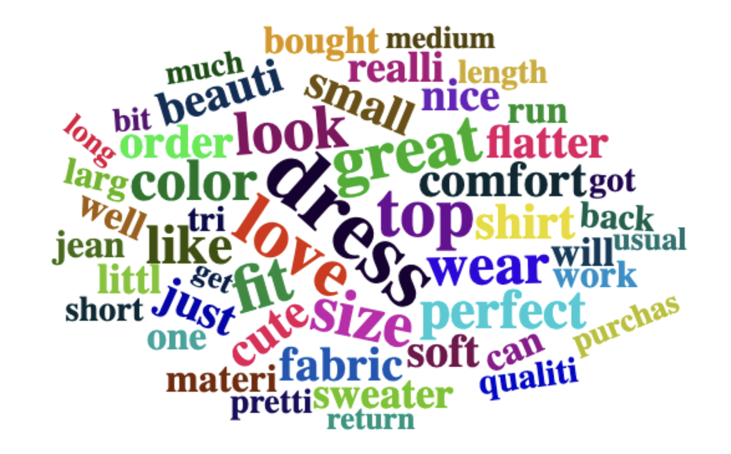

```r
# install.packages("wordcloud2")
library(wordcloud2)
# convert tfidf to a matrix
m <- as.matrix(tfidf)

# find out the importance of each term by summing up the tf-idf scores over the corpus
v <- sort(colSums(m),decreasing=TRUE)
importance <- data.frame(word = names(v), tfidf = v)

# only keep the top 50 words to make the wordcloud readable
k <- 50
importance_top <- importance[1:k, ]

wordcloud2(importance_top, size = 0.5)
```